# Presentation

Yu Du

## Introduction

- The data is collected from the FEMA website
- The orginial Data contains 22 columns with over 700,000 rows
- very large dataset

## Important Columns for mapping

- Variables: year, state,county
- Outcomes: project Amount, federal share obligated
- project Amount:The estimated total cost of the Public Assistance grant project in dollars
- federal share obligated:The Public Assistance grant funding available to the grantee (State) in dollars

## Goal

- Calculate the total of two outcomes (project Amount, federal share obligated) in each county from 2009 to 2020
- Look at if there is any trend
- Compare two maps

## Data Cleaning Steps

step one - choose the ‘Hurricane’ as the incident of type - the incident type will affect the types of assistance available

step two - choose the year from 2009 to 2020

## Plot the total project Amount from 2009 to 2020

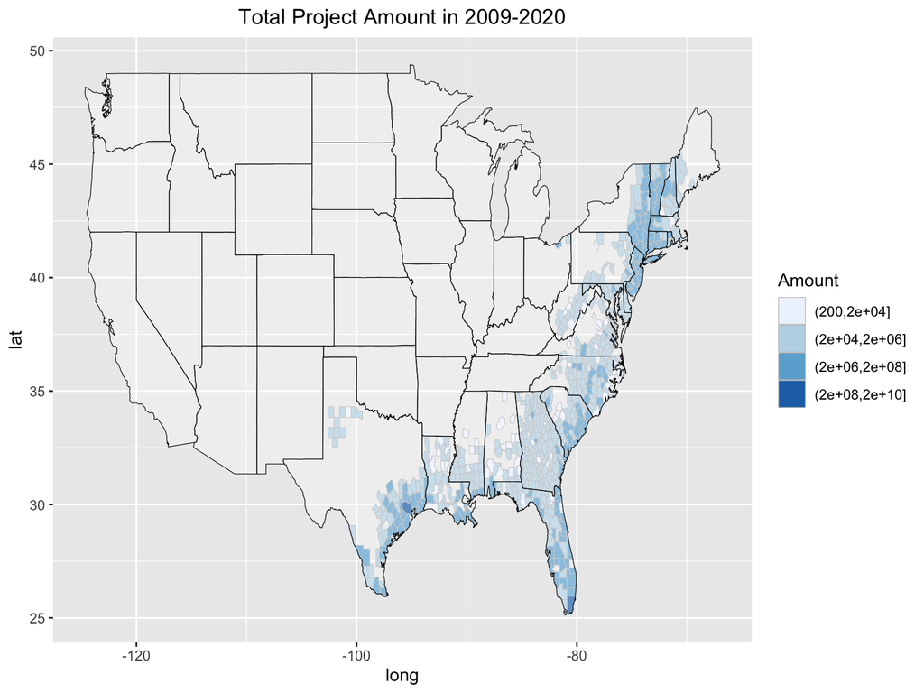

## Plot the total federal share obligated from 2009 to 2020.

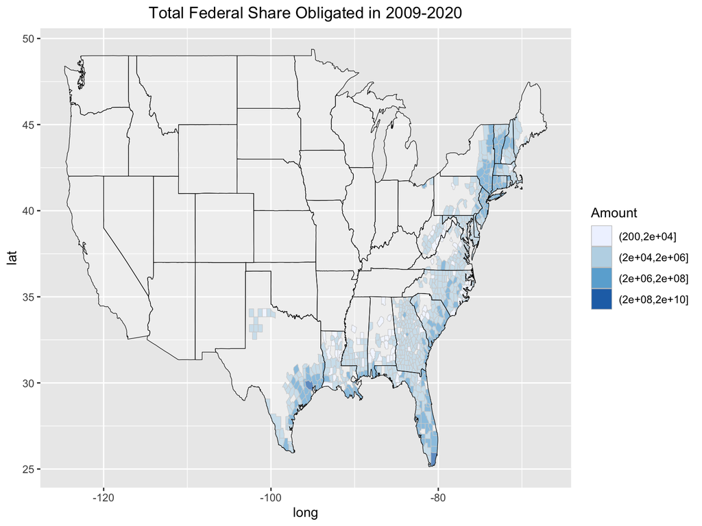

## ShinyApp

contains ggplotly maps: https://ydu199.shinyapps.io/Mapping/

## Results/Observations

- The southeast US suffers the incident ‘Hurricane’.
- Coastal counties tend to have higher project amount and federal share obligated from 2009 to 2020.
- In some counties, total project amount is higher than total federal share obligated from 2009 to 2020.

## What can improve or add

- can set time intervals in 2009-2020 to look at the data more specifically.
- can look at other incidents to find if some might have the similar result.